# feiyaw_FinalHomeworkCode_05

Feiya Wang

11/10/2019

## Homework 5

Introduction: This is the code for [Homework 05](https://fuzzyatelin.github.io/bioanth-stats/homework-05.html), on week 9 of AN597

#Question 1: Bootstrapping Standard Errors and CIs for Linear Models. When we initially discussed the central limit theorem and confidence intervals, we showed how we could use bootstrapping to estimate standard errors and confidence intervals around certain parameter values, like the mean. Using bootstrapping, we could also do the same for estimating standard errors and CIs around regression parameters, such as β coefficients.

> [1] Using the “KamilarAndCooperData.csv” dataset, run a linear regression looking at log(HomeRange_km2) in relation to log(Body_mass_female_mean) and report your β coeffiecients (slope and intercept).

First, we load the files.

```r
library (curl)
#install package curl before this step to load a file from server.
f <- curl("https://raw.githubusercontent.com/fuzzyatelin/fuzzyatelin.github.io/master/AN597_Fall19/KamilarAndCooperData.csv")
#load the file in varibale f
d <- read.csv(f, header = TRUE, sep = ",", stringsAsFactors = FALSE)
# read file in d as a dataframe.
head(d)
```

```
##               Scientific_Name          Family          Genus      Species
## 1 Allenopithecus_nigroviridis Cercopithecidae Allenopithecus nigroviridis
## 2         Allocebus_trichotis Cercopithecidae      Allocebus    trichotis
## 3           Alouatta_belzebul        Atelidae       Alouatta     belzebul
## 4             Alouatta_caraya        Atelidae       Alouatta       caraya
## 5            Alouatta_guariba        Atelidae       Alouatta      guariba
## 6           Alouatta_palliata        Atelidae       Alouatta     palliata
##   Brain_Size_Species_Mean Brain_Size_Female_Mean   Brain_size_Ref
## 1                   58.02                  53.70 Isler et al 2008
## 2                      NA                     NA
## 3                   52.84                  51.19 Isler et al 2008
## 4                   52.63                  47.80 Isler et al 2008
## 5                   51.70                  49.08 Isler et al 2008
## 6                   49.88                  48.04 Isler et al 2008
##   Body_mass_male_mean Body_mass_female_mean Mass_Dimorphism
```

[output cut: 69 more lines]

Then, for the linear regression

```r
library(ggplot2)
attach(d)

p1 <- ggplot(data=d, aes(x=log(HomeRange_km2),y=log(Body_mass_female_mean)))
# build a ggplot object
p1 <- p1 + geom_point()
# make a scatterplot
p1 <- p1 + geom_smooth(method="lm", fullrange=TRUE)
# add a regression line
m1<-lm(data=d,log(HomeRange_km2)~log(Body_mass_female_mean))
# make the model of two variable
t1 <- unlist(m1$coefficients)
# unlist m to get coeffient

beta0<-round(t1[1],digits = 3)
#round beta 0 to 3 decimal place

beta0
```

```
## (Intercept)
##      -9.441
```

```r
#beta 0 coefficient

beta1<-round(t1[2],digits = 3)
#round beta 1 to 3 decimal place

beta1
```

```
## log(Body_mass_female_mean)
##                      1.036
```

[figure not shown]

```r
#beta 1 coefficient

soe1<-paste("y=",as.character(beta1),"x",as.character(beta0))
#make the regression equation as a string

p1<-p1+annotate("text", label = soe1, x = -4, y = 12, size = 5, colour = "black")
#add it to the ggplot

p1
```

```r
detach(d)
#end for attach.
```

> [2] Then, use bootstrapping to sample from your data 1000 times with replacement, each time fitting the same model and calculating the same coefficients. This generates a sampling distribution for each β coefficient.

```r
library(boot)
#install the package of bootstrap
attach(d)

statistic <- function(formula, data, indices) {
    d <- data[indices,]
    fit <- lm(log(HomeRange_km2)~log(Body_mass_female_mean), data=d)
    return(coef(fit))
}
# function for statistic in boot()

results <- boot(data=d, statistic, R=1000,formula=log(HomeRange_km2)~log(Body_mass_female_mean))
#use boot() to apply for the results
results
```

```
##
## ORDINARY NONPARAMETRIC BOOTSTRAP
##
##
## Call:
## boot(data = d, statistic = statistic, R = 1000, formula = log(HomeRange_km2) ~
##     log(Body_mass_female_mean))
##
##
## Bootstrap Statistics :
##      original       bias    std. error
## t1* -9.441231 -0.011762033  0.61770963
## t2*  1.036432  0.001395271  0.07972579
```

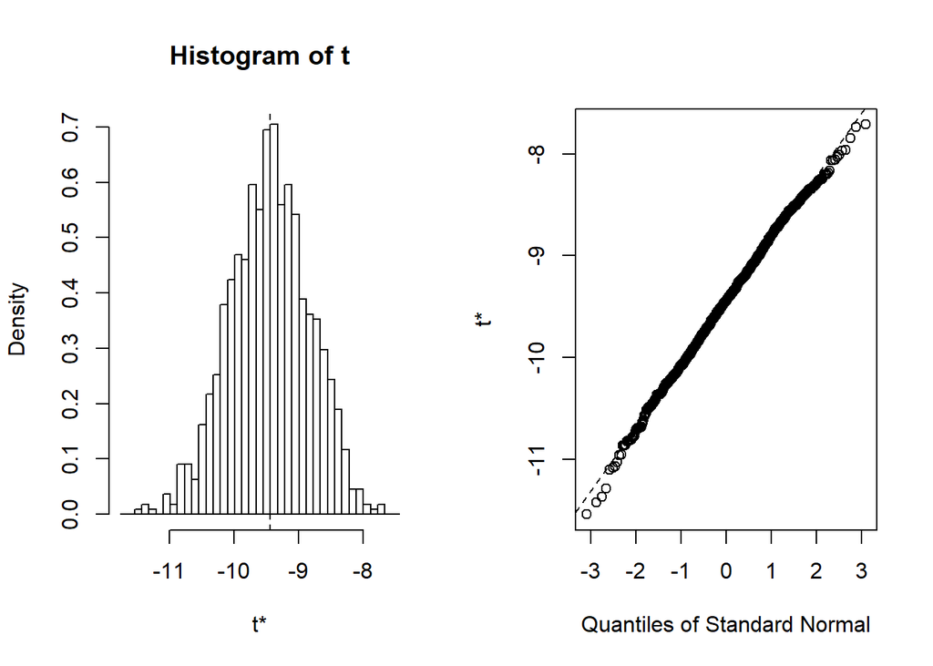

```r
p1=plot(results, index=1)
```

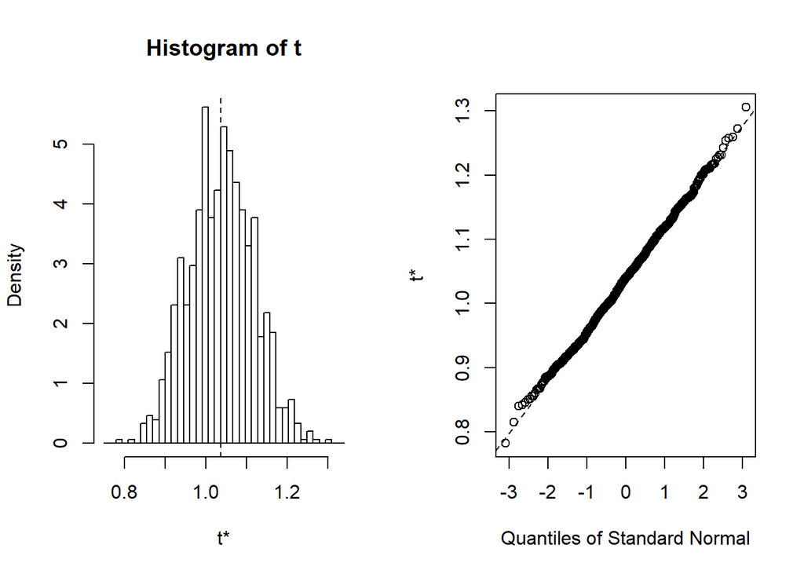

```r
#beta 0 sample distribution

p2=plot(results, index=2)
```

```r
#beta 1 sample distribution

detach(d)
#end of attach
```

# Five challenge:

1. I am not familiar with bootstapping and i use google to find a package to deal with it.
2. I do not have enough time to do the extra credit. if i have time, i will do it next week.